# Презентация по лабораторной работе №1

Основы информационной безопасности

Ахатов Э.Э.

1 мая 2026

## Цель

Выполнение контрольных заданий первого блока курса “Основы Кибербезопасности”

## Задание

выполнить задания курса

## 1 вопрос

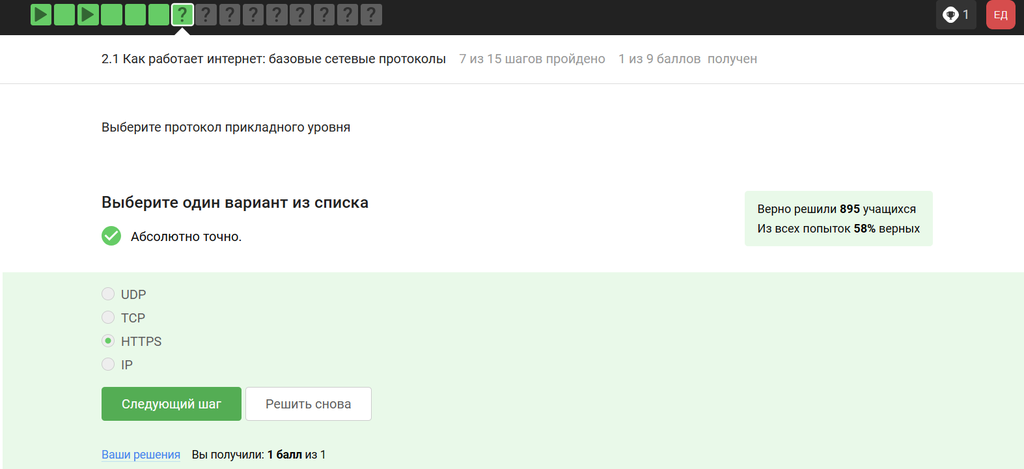

Вопрос 2.1.1

Tcp - transmission control protocol - работает на транспортном уровне

## 2 вопрос

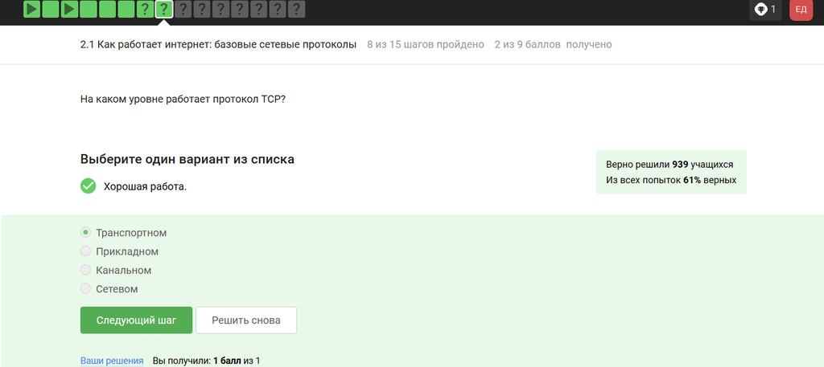

Вопрос 2.1.2

В адрессе типа Ipv4 не может быть чисел больше 255

## 3 вопрос

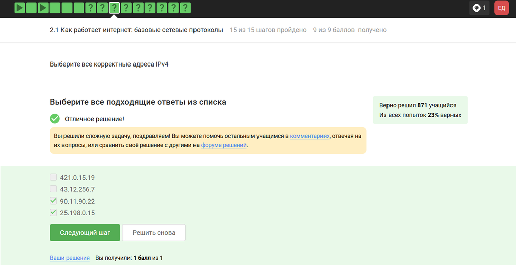

Вопрос 2.1.3

Dns-сервер - приложение предназначенное для ответов на днс запросы

## 4 вопрос

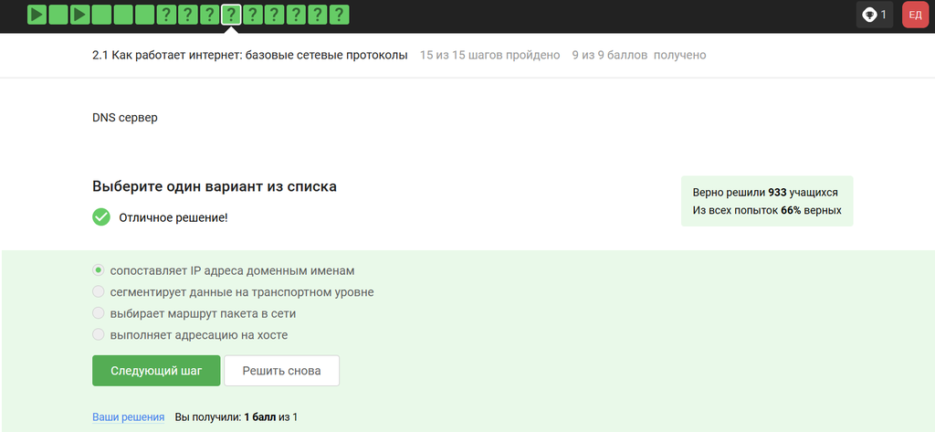

Вопрос 2.1.4

распределение протоколов в модели TCP/IP:

- Прикладной уровень: HTTP,RTSP,FTP,DNS
- Транспортный уровень: TCP, UDP, SCTP, DCCP
- Уровень сетевого доступа: Ethernet, IEE 802.11, WLAN, SLIP,ATM

## 5 вопрос

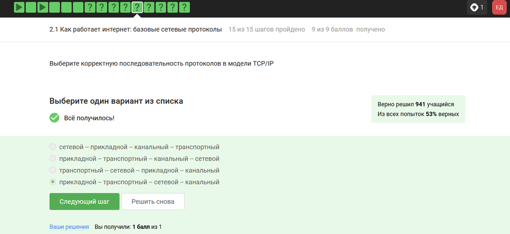

Вопрос 2.1.5

Протокол HTTP передает не зашифрованные данные, а протокол уже будет передавать зашифрованные

## 6 вопрос

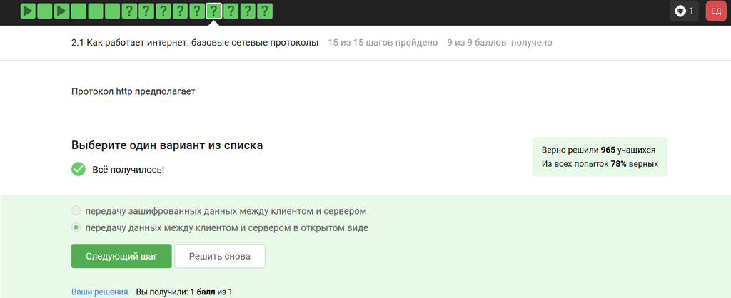

Вопрос 2.1.6

одна из фаз передача данных, другая должна быть рукопожатием

## 7 вопрос

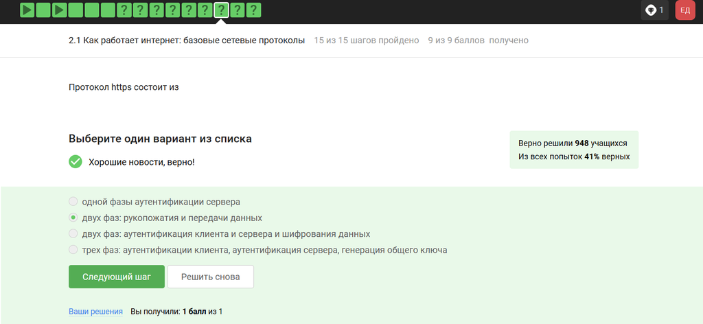

Вопрос 2.1.7

TLS определяется и клиентом и сервером

## 8 вопрос

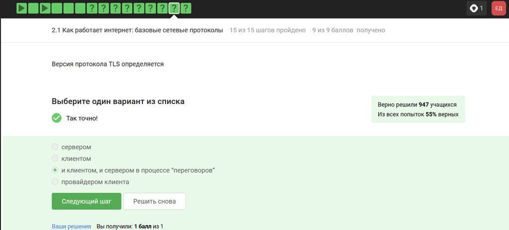

Вопрос 2.1.8

## 9 вопрос

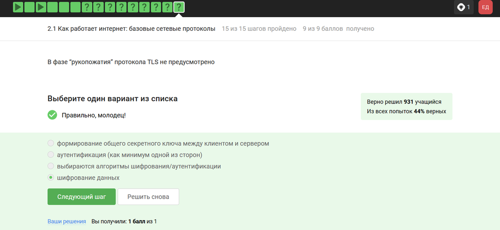

Вопрос 2.1.9

## 10 вопрос

куки точно не хранят пароли и айпи адреса

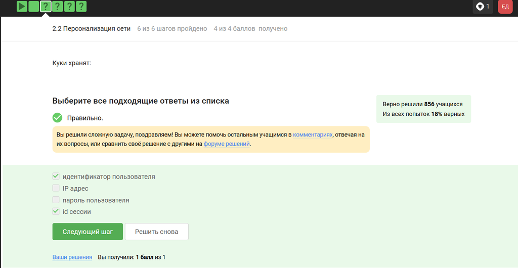

Вопрос 2.2.1

куки не делают соединение более надежным

## 11 вопрос

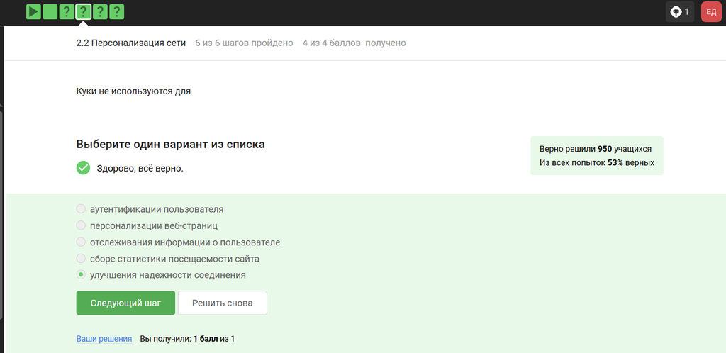

Вопрос 2.2.2

ответ на изображении

## 12 вопрос

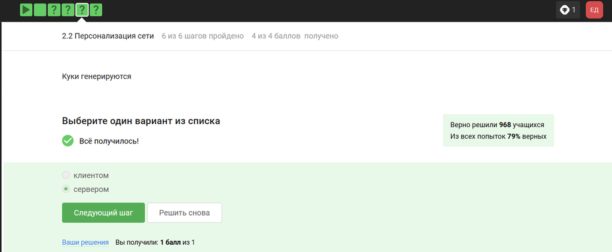

Вопрос 2.2.3

Сессионные куки хранятся в течение сессии

## 13 вопрос

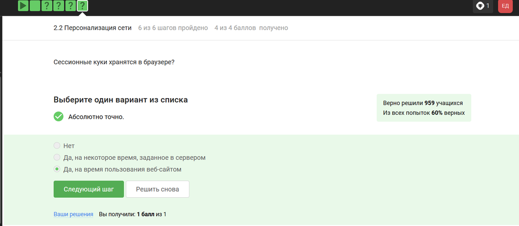

Вопрос 2.2.4

Необходимо три узла-входной,промежуточный и выходной

## 14 вопрос

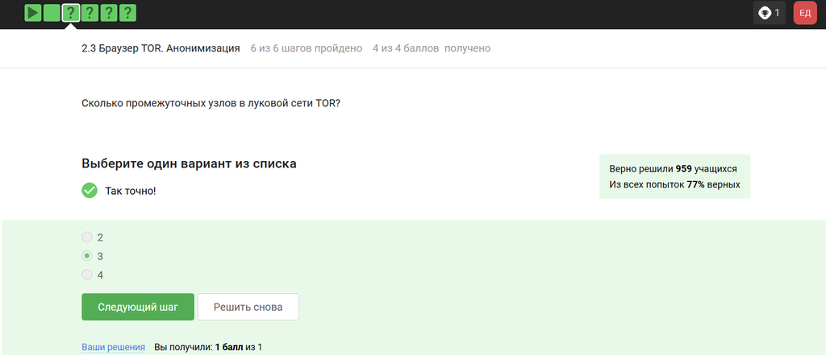

Вопрос 2.3.1

айпи адрес не должен быть известен охранному и промежуточному узлам

## 15 вопрос

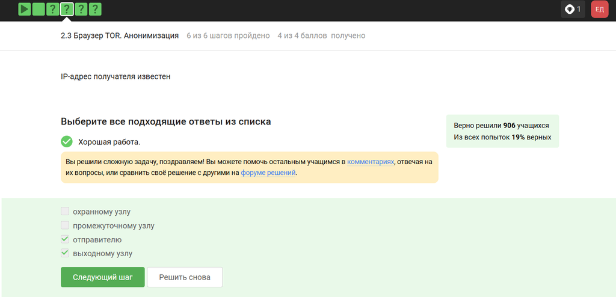

Вопрос 2.3.2

Отправитель генерирует общий секретный ключ

## 16 вопрос

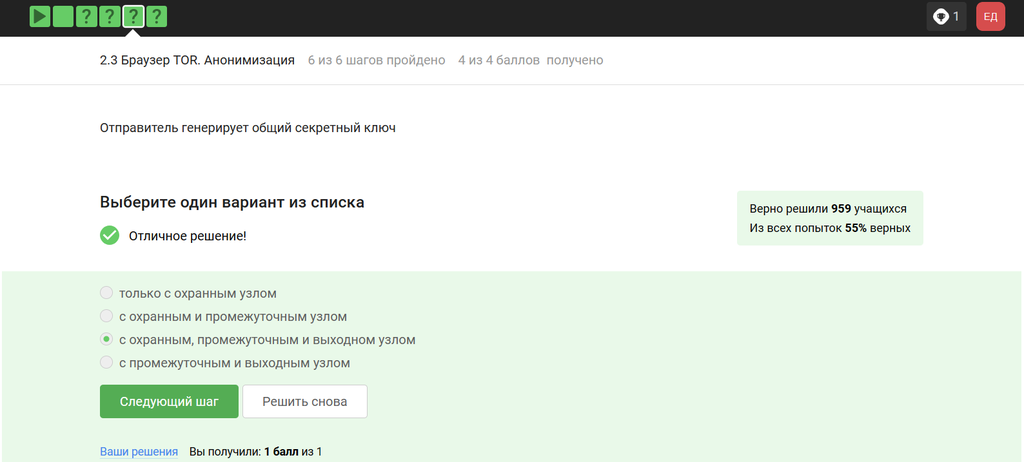

Вопрос 2.3.3

для получения пакетов не нужно использовать тор

## 17 вопрос

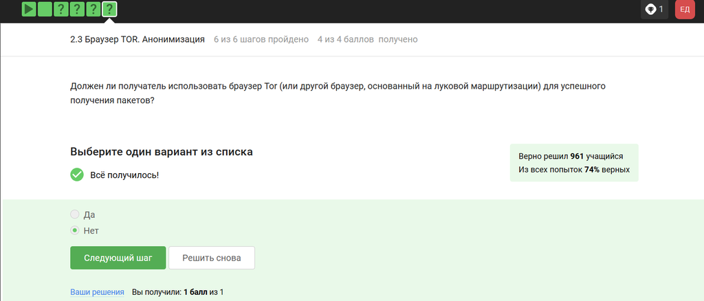

Вопрос 2.3.4

Действительно, это определение WI-FI

## 18 вопрос

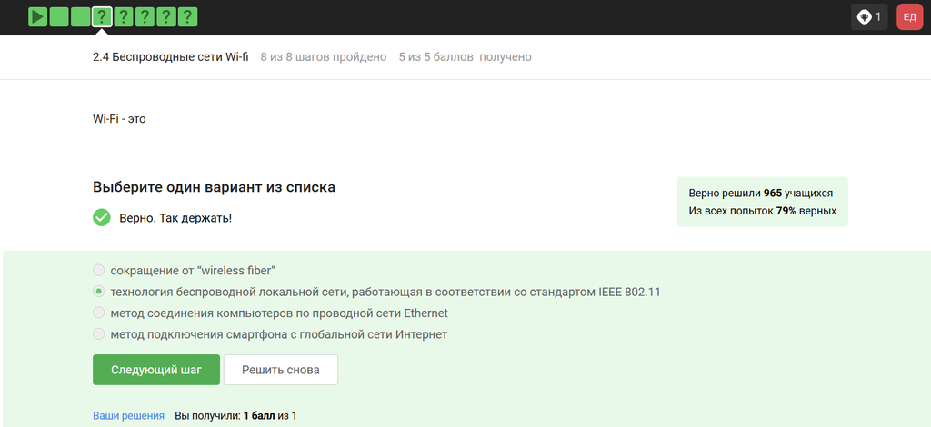

Вопрос 2.4.1

он распологается как канальный уровень

## 19 вопрос

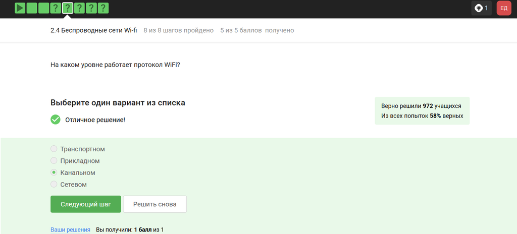

Вопрос 2.4.2

это устаревший и небезопасный метод проверки подлинности

## 20 вопрос

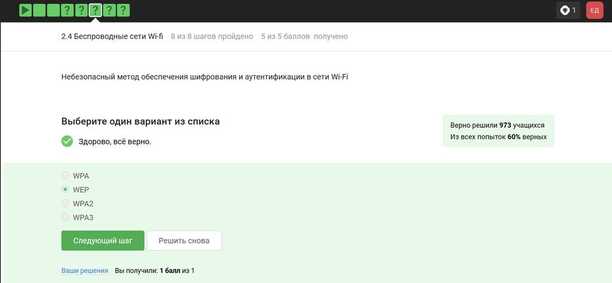

Вопрос 2.4.3

Нужно аутентифицировать устройства и позже передаются зашифрованные данные

## 21 вопрос

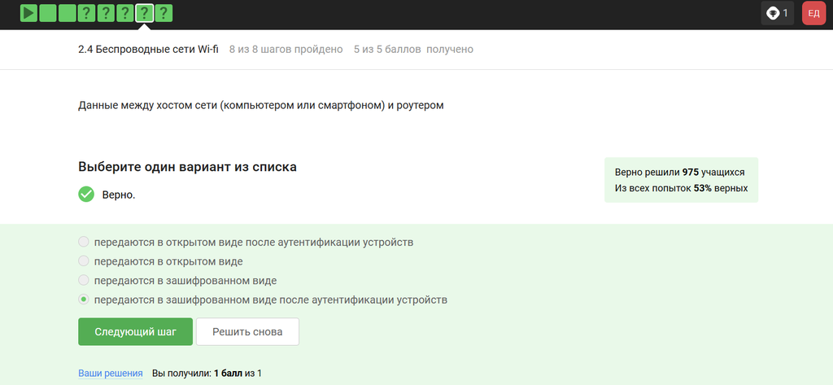

Вопрос 2.4.4

для личного использования

## 22 вопрос

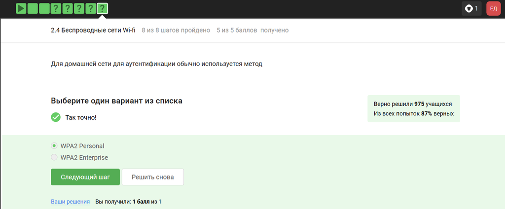

Вопрос 2.4.5

## Вывод

В ходе выполнения работы я узнал о работе сетевых протоколов, куки, сетей и браузера ТОР